# HW6 - Busayo

Olubusayo Bolonduro

9/1/2020

For this assignment I decided to play with NFL data again.

# Mitchell Trubisky

In the 2017 NFL Draft, the Chicago Bears selected Mitchell Trubisky with the number 2 overall pick. Now, three years later, the man without a middle name is in a fight to be named starting quarterback. After an impressive sophomore season that helped the Bears claim a 12-4 record and their first playoff appearance since 2010, Trubisky regressed in year 3 and was unable to continue his trend of growth at the QB position.

```r
library(tidyverse)
library(na.tools)
library(ggimage)
```

```r
#Read in data
yr2019pbp <- read_csv(url("https://github.com/ryurko/nflscrapR-data/raw/master/play_by_play_data/regular_season/reg_pbp_2019.csv"))
yr2018pbp <- read_csv(url("https://github.com/ryurko/nflscrapR-data/raw/master/play_by_play_data/regular_season/reg_pbp_2018.csv"))

Passing_2019 <- yr2019pbp %>%
  select(play_type, posteam,yards_gained, air_yards, pass_location, desc)
Trubisky_or_False_2019 <- Passing_2019 %>%
  filter(play_type=="pass", posteam =="CHI", grepl("Trubisky",desc))%>%
  #Added a column for whether the pass was completed or not
  mutate(Completion = (!grepl("incomplete",desc)))%>%
  drop_na()%>%
  group_by(pass_location)
```

Trubisky is often subject to criticism regarding his accurracy on downfield passing. I’m going to create an arbitrary metric called the Money-Mitch-Throw (MMT) that occurs whenever Mitchell Trubisky throws a completed pass that travels at least 20 yards in the air. Let’s see how many times a MMT occured during the 2019 season.

```r
#Here I create a for loop that counts the total number of MMTs
MMT_2019 <- 0
completed_air_yards_2019 <-Trubisky_or_False_2019%>%
  select(air_yards,Completion)%>%
  filter(Completion == TRUE)
list_air_yards_2019 <- dplyr::pull(completed_air_yards_2019,air_yards)
for (pass in list_air_yards_2019){
  if (pass >=20) {
    MMT_2019 <- MMT_2019 +1
  }
}
#Function to give MMT output rounded to 1 significant figure
MMT_Rate <-function(MMTpasses,TotalPasses) {
  a <- MMTpasses
  b <- TotalPasses
  c <- a/b *100
  return(sprintf(c, fmt = '%#.1f'))
}
```

Looks like a MMT occurred 24 times out of 513 pass attempts (4.7 percent of pass attempts) last season. Let’s see how that number compares to his 2018 season.

```r
MMT_2018 <- 0
Passing_2018 <- yr2018pbp %>%
  select(play_type, posteam,yards_gained, air_yards, pass_location, desc)
Trubisky_or_False_2018 <- Passing_2018 %>%
  filter(play_type=="pass", posteam =="CHI", grepl("Trubisky",desc))%>%
  mutate(Completion = (!grepl("incomplete",desc)))%>%
  drop_na()%>%
  group_by(pass_location)
completed_air_yards_2018 <-Trubisky_or_False_2018%>%
  select(air_yards,Completion)%>%
  filter(Completion == TRUE)
list_air_yards_2018 <- dplyr::pull(completed_air_yards_2018,air_yards)
for (pass in list_air_yards_2018){
  if (pass >= 20) {
    MMT_2018 <- MMT_2018 +1
  }
}
```

In 2018, there a MMT occurred on 28 out of 432 pass attempts (6.5 percent of pass attempts). Downfield passing appears to be a skill that declined for Trubisky in 2019. Let’s compare that to the league average.

```r
MMT_All <- 0
Passing_2019 <- yr2019pbp %>%
  select(play_type,yards_gained, posteam, air_yards, pass_location, desc)
All_2019 <- Passing_2019 %>%
  #Remove Trubisky from all 2019 pass data
  filter(play_type=="pass", !grepl("Trubisky", desc))%>%
  mutate(Completion = (!grepl("incomplete",desc)))%>%
  drop_na()%>%
  group_by(pass_location)
completed_air_yards_2019 <-All_2019%>%
  select(air_yards,Completion)%>%
  filter(Completion == TRUE)
list_air_yards_2019 <- dplyr::pull(completed_air_yards_2019,air_yards)
for (pass in list_air_yards_2019){
  if (pass >= 20) {
    MMT_All <- MMT_All +1
  }
}
```

The league average for a “Money-Mitch-Throw” last season was at 5.1 percent, slightly above the rate that Trubisky posted. [Coincidentally, I found an article highlighting the top deep passers from the 2019 season](https://www.nfl.com/news/dak-prescott-russell-wilson-headline-nfl-s-top-10-deep-passers) that also decided to evaluate deep passing based off of passes traveling 20+ yards in the air! For fun, I also decided to see how Russell Wilson, who is considered the best deep-passer in the NFL, compares with his MMT rate for the 2019 season.

```r
MMT_Russ <- 0
Passing_2019 <- yr2019pbp %>%
  select(play_type, posteam,yards_gained, air_yards, pass_location, desc)
Trust_Russ_2019 <- Passing_2019 %>%
  filter(play_type=="pass", posteam =="SEA", grepl("Wilson",desc))%>%
  ##Added a column for whether the pass was completed or not
  mutate(Completion = (!grepl("incomplete",desc)))%>%
  drop_na()%>%
  group_by(pass_location)
completed_air_yards_2019 <-Trust_Russ_2019%>%
  select(air_yards,Completion)%>%
  filter(Completion == TRUE)
list_air_yards_2019 <- dplyr::pull(completed_air_yards_2019,air_yards)
for (pass in list_air_yards_2019){
  if (pass >= 20) {
    MMT_Russ <- MMT_Russ +1
  }
}
```

Russell Wilson’s 6.4 percent MMT rate puts into perspective how impressive Trubisky’s 2018 season was, and how underwhelming his campaign the following year was.

Lastly, I wanted to see visualize Trubisky’s 2019 passing based on location, distance, and accuracy.

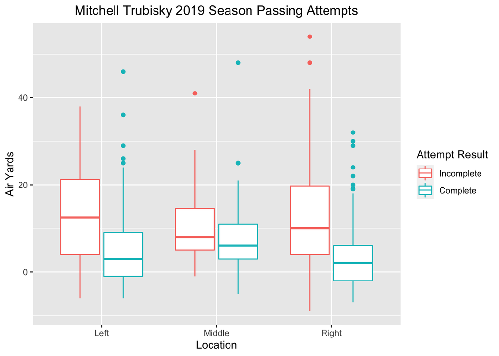

```r
Money_Mitch_Plot <- ggplot(Trubisky_or_False_2019, aes(pass_location, air_yards, color = as.factor(Completion)))+
  geom_boxplot()+
  labs(x = "Pass Location", y ="Air Yards",title = "Mitchell Trubisky 2019 Season Passing Attempts")+
  scale_color_discrete(name = "Attempt Result", labels = c("Incomplete","Complete"))+
  scale_x_discrete(name = "Location", labels= c("Left","Middle","Right"))+
  theme(plot.title = element_text(hjust = 0.5))

Money_Mitch_Plot
```

The unsurprising trend here is that Trubisky’s completion rate decreases as the distance of the throw increases. I wonder if there are any outlier quarterbacks that show an opposite trend at a certain location of the field.

Regardless, best of luck to the Bears this season. They won’t be better than the Seahawks but football is always more fun when the local team is playing well.